# Abortion and Victimhood - Pilot Results

Cristian Rodriguez

July 26, 2019

Pilot sample: 163 MTurkers (7/18/19)

## Descriptives

### Demographics

| Variable | Stats / Values | Freqs (% of Valid) | Graph | Valid | Missing |
| --- | --- | --- | --- | --- | --- |
| Sex [factor] | 1. Male 2. Female | 90 (55.2%) 73 (44.8%) |  | 163 (100%) | 0 (0%) |
| SexOr [factor] | 1. Heterosexual 2. LGBT+ | 133 (81.6%) 30 (18.4%) |  | 163 (100%) | 0 (0%) |
| Age [numeric] | Mean (sd) : 35.2 (10.1) min < med < max: 20 < 32 < 66 IQR (CV) : 12 (0.3) | 41 distinct values |  | 163 (100%) | 0 (0%) |
| Edu_Cat [factor] | 1. > HS 2. HS 3. Some College 4. 2y College 5. 4y College 6. MS 7. PhD or Professional | 33 (20.2%) 24 (14.7%) 19 (11.7%) 22 (13.5%) 9 ( 5.5%) 20 (12.3%) 36 (22.1%) |  | 163 (100%) | 0 (0%) |
| Party [factor] | 1. Republican 2. Democrat 3. Independent / Other | 50 (30.7%) 70 (42.9%) 43 (26.4%) |  | 163 (100%) | 0 (0%) |
| Marital [factor] | 1. Single 2. Married 3. Divorced | 50 (30.7%) 107 (65.6%) 6 ( 3.7%) |  | 163 (100%) | 0 (0%) |
| Rel_Person [integer] | Mean (sd) : 3.2 (1.4) min < med < max: 1 < 3 < 5 IQR (CV) : 3 (0.5) | 1 : 22 (13.5%) 2 : 43 (26.4%) 3 : 31 (19.0%) 4 : 19 (11.7%) 5 : 48 (29.4%) |  | 163 (100%) | 0 (0%) |

### Overview of Variables of Interest

| Variable | Stats / Values | Freqs (% of Valid) | Graph | Valid | Missing |
| --- | --- | --- | --- | --- | --- |
| Elective [numeric] | Mean (sd) : 0 (2) min < med < max: -2.7 < -0.3 < 3.3 IQR (CV) : 3.6 (77.3) | 118 distinct values |  | 163 (100%) | 0 (0%) |
| Preventive [numeric] | Mean (sd) : 0 (1.7) min < med < max: -2.1 < -0.2 < 4.1 IQR (CV) : 2.5 (95) | 120 distinct values |  | 163 (100%) | 0 (0%) |
| Traumatic [numeric] | Mean (sd) : 0 (1) min < med < max: -1 < -0.3 < 3.4 IQR (CV) : 1.3 (-49.8) | 104 distinct values |  | 163 (100%) | 0 (0%) |
| Natural [numeric] | Mean (sd) : 0 (0.9) min < med < max: -1.1 < -0.2 < 3.3 IQR (CV) : 1 (33.1) | 124 distinct values |  | 163 (100%) | 0 (0%) |
| Mind [numeric] | Mean (sd) : 0.2 (1.3) min < med < max: -2.5 < 0.3 < 2.4 IQR (CV) : 2 (8.2) | 135 distinct values |  | 163 (100%) | 0 (0%) |
| Ab_OK [numeric] | Mean (sd) : 3.6 (1.9) min < med < max: 1 < 3.6 < 7 IQR (CV) : 3.4 (0.5) | 31 distinct values |  | 163 (100%) | 0 (0%) |
| Victimhood [numeric] | Mean (sd) : 4.6 (0.7) min < med < max: 3.2 < 4.5 < 6.5 IQR (CV) : 0.9 (0.2) | 52 distinct values |  | 163 (100%) | 0 (0%) |

### Zero-order Correlations across variables

|  | Ab: Elect | Ab: Trev | Ab:Traum | FP: Mind-like | FP: Natural-like | Sc: Ab is OK | Sc: Victim | Sc: Unwant | Sc: Child suffers | Sc: Woman suffers | Trade Off | Ideology | Religiosity |
| --- | --- | --- | --- | --- | --- | --- | --- | --- | --- | --- | --- | --- | --- |
| Ab: Elect |  |  |  |  |  |  |  |  |  |  |  |  |  |
| Ab: Trev | 0.85 (<.001) |  |  |  |  |  |  |  |  |  |  |  |  |
| Ab:Traum | 0.63 (<.001) | 0.80 (<.001) |  |  |  |  |  |  |  |  |  |  |  |
| FP: Mind-like | 0.11 (.15) | 0.15 (.06) | -0.04 (.62) |  |  |  |  |  |  |  |  |  |  |
| FP: Natural-like | -0.10 (.19) | -0.07 (.37) | -0.03 (.73) | 0.47 (<.001) |  |  |  |  |  |  |  |  |  |
| Sc: Ab is OK | 0.67 (<.001) | 0.65 (<.001) | 0.69 (<.001) | -0.21 (.01) | -0.16 (.05) |  |  |  |  |  |  |  |  |
| Sc: Victim | -0.48 (<.001) | -0.43 (<.001) | -0.20 (.01) | -0.40 (<.001) | -0.16 (.04) | -0.24 (<.001) |  |  |  |  |  |  |  |
| Sc: Unwant | 0.13 (.11) | 0.11 (.15) | 0.04 (.65) | 0.45 (<.001) | 0.25 (<.001) | 0.06 (.45) | -0.41 (<.001) |  |  |  |  |  |  |
| Sc: Child suffers | -0.44 (<.001) | -0.46 (<.001) | -0.30 (<.001) | -0.42 (<.001) | -0.00 (.99) | -0.22 (<.001) | 0.57 (<.001) | -0.22 (.01) |  |  |  |  |  |
| Sc: Woman suffers | 0.08 (.33) | 0.11 (.15) | 0.31 (<.001) | -0.37 (<.001) | 0.02 (.76) | 0.31 (<.001) | 0.38 (<.001) | -0.33 (<.001) | 0.30 (<.001) |  |  |  |  |
| Trade Off | 0.02 (.80) | -0.01 (.91) | 0.02 (.81) | 0.04 (.65) | -0.09 (.26) | -0.04 (.61) | -0.03 (.71) | 0.10 (.20) | -0.14 (.07) | -0.13 (.09) |  |  |  |
| Ideology | 0.28 (<.001) | 0.29 (<.001) | 0.32 (<.001) | -0.31 (<.001) | -0.16 (.04) | 0.40 (<.001) | 0.05 (.49) | -0.33 (<.001) | 0.04 (.63) | 0.29 (<.001) | 0.02 (.85) |  |  |
| Religiosity | -0.25 (<.001) | -0.26 (<.001) | -0.38 (<.001) | 0.28 (<.001) | 0.09 (.26) | -0.40 (<.001) | -0.06 (.48) | 0.11 (.17) | -0.05 (.49) | -0.32 (<.001) | 0.01 (.94) | -0.54 (<.001) |  |
| Computed correlation used pearson-method with listwise-deletion. |  |  |  |  |  |  |  |  |  |  |  |  |  |

### Confirmatory Factor Analysis

- Abortion Attitudes

  |  | chisq d | f r | msea | srmr | cfi | tli | aic | bic |
  | --- | --- | --- | --- | --- | --- | --- | --- | --- |
  | OneF | 594.486 | 54 | 0.230 | 0.122 | 0.746 | 0.689 | 7672.556 | 7750.358 |
  | TwoF | 350.838 | 53 | 0.172 | 0.098 | 0.860 | 0.826 | 7430.909 | 7511.952 |
  | ThreeF | 166.108 | 51 | 0.109 | 0.056 | 0.946 | 0.930 | 7250.178 | 7337.705 |

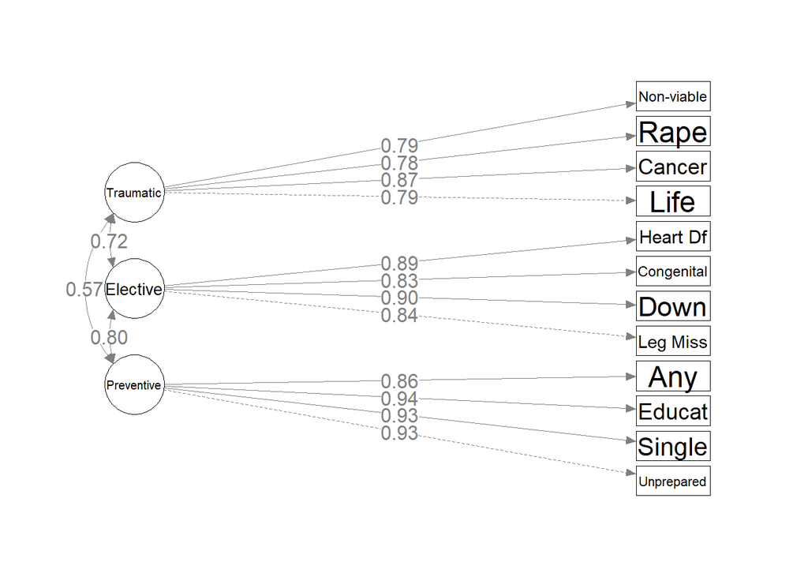

- Fetal Personhood

  |  | chisq d | f r | msea | srmr | cfi | tli | aic | bic |
  | --- | --- | --- | --- | --- | --- | --- | --- | --- |
  | OneF | 400.083 | 35 | 0.235 | 0.171 | 0.655 | 0.556 | 6701.013 | 6765.848 |
  | TwoF | 136.521 | 34 | 0.126 | 0.098 | 0.903 | 0.872 | 6439.450 | 6507.527 |

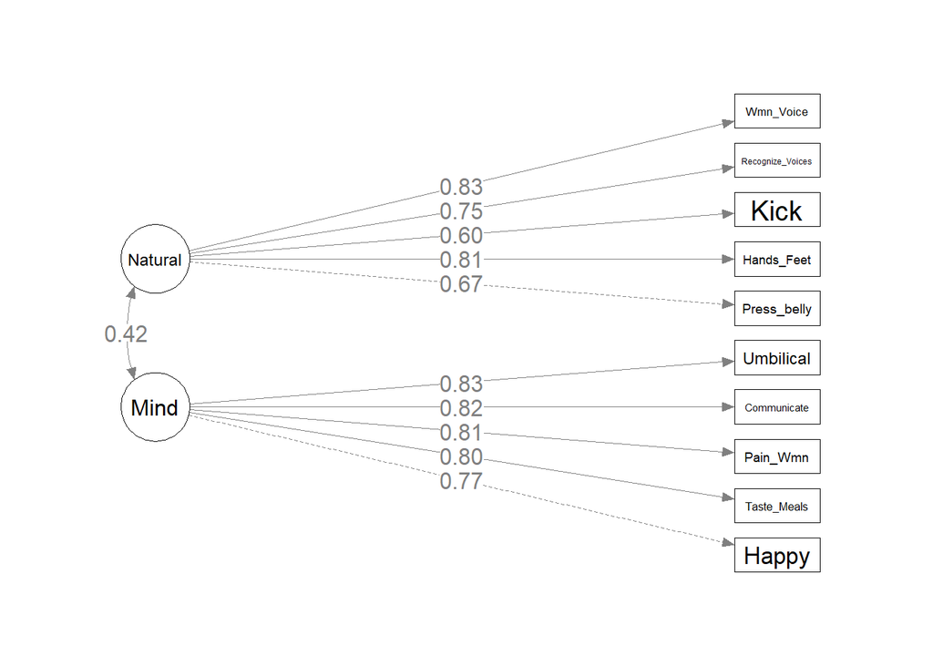

## Analyses

These regressions had identical patterns with or without demographics (Gender, Age, Sexual Orientation, Educational Level, Marital Status, Self/Partner ever been pregnant, Self/Partner ever had an abortion, Having Children, Number of Children). The following models were conducted without demographics.

Model 1: Ideology and Religiosity (in 2 items)  
Model 2 adds: Mind-like and Natural traits attributed to the Fetus  
Model 3 adds: Expectations of the Child suffering and the Woman suffering  
Model 4 adds: Perceived Victimhood and Unwantedness of the pregnancy

### Elective Abortion

Outcome: Elective Abortion

|  | Model 1 |  |  | Model 2 |  |  | Model 3 |  |  | Model4 |  |  |
| --- | --- | --- | --- | --- | --- | --- | --- | --- | --- | --- | --- | --- |
| Predictors | Beta | standardized 95% CI | p | Beta | standardized 95% CI | p | Beta | standardized 95% CI | p | Beta | standardized 95% CI | p |
| Ideology | 0.25 | 0.09,0.41 | **0.003** | 0.28 | 0.12,0.44 | **0.001** | 0.21 | 0.07,0.36 | **0.004** | 0.19 | 0.06,0.33 | **0.005** |
| Church att | 0.22 | -0.03,0.47 | 0.089 | 0.14 | -0.10,0.38 | 0.244 | 0.13 | -0.09,0.34 | 0.264 | 0.15 | -0.05,0.34 | 0.148 |
| Rel Person | -0.28 | -0.53,-0.04 | **0.026** | -0.37 | -0.61,-0.13 | **0.003** | -0.33 | -0.55,-0.11 | **0.004** | -0.35 | -0.55,-0.15 | **0.001** |
| Mind |  |  |  | 0.41 | 0.23,0.59 | **<0.001** | 0.21 | 0.02,0.40 | **0.028** | 0.17 | -0.01,0.34 | 0.060 |
| Natural |  |  |  | -0.21 | -0.37,-0.05 | **0.012** | -0.14 | -0.29,0.02 | 0.081 | -0.21 | -0.35,-0.07 | **0.003** |
| Ch suff |  |  |  |  |  |  | -0.43 | -0.58,-0.29 | **<0.001** | -0.21 | -0.36,-0.06 | **0.006** |
| Wm suff |  |  |  |  |  |  | 0.15 | 0.00,0.30 | **0.049** | 0.27 | 0.14,0.41 | **<0.001** |
| Victimhood |  |  |  |  |  |  |  |  |  | -0.45 | -0.60,-0.30 | **<0.001** |
| UW |  |  |  |  |  |  |  |  |  | 0.08 | -0.06,0.22 | 0.256 |
| Observations | 163 |  |  | 163 |  |  | 163 |  |  | 163 |  |  |
| R<sup>2</sup> / adjusted R<sup>2</sup> | 0.105 / 0.088 |  |  | 0.208 / 0.182 |  |  | 0.352 / 0.323 |  |  | 0.490 / 0.460 |  |  |

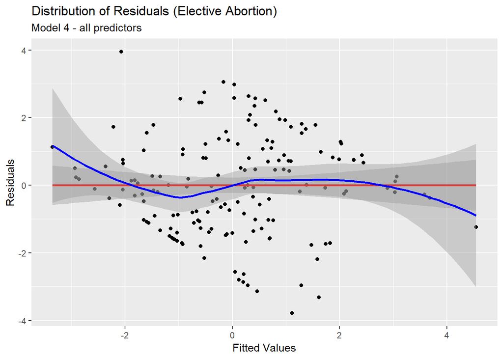

### Preventive Abortion

Outcome: Preventive Abortion

|  | Model 1 |  |  | Model 2 |  |  | Model 3 |  |  | Model4 |  |  |
| --- | --- | --- | --- | --- | --- | --- | --- | --- | --- | --- | --- | --- |
| Predictors | Beta | standardized 95% CI | p | Beta | standardized 95% CI | p | Beta | standardized 95% CI | p | Beta | standardized 95% CI | p |
| Ideology | 0.25 | 0.09,0.42 | **0.003** | 0.29 | 0.13,0.44 | **<0.001** | 0.21 | 0.08,0.35 | **0.003** | 0.20 | 0.07,0.34 | **0.004** |
| Church att | 0.04 | -0.21,0.29 | 0.741 | -0.04 | -0.27,0.20 | 0.752 | -0.05 | -0.26,0.16 | 0.632 | -0.03 | -0.23,0.16 | 0.730 |
| Rel Person | -0.14 | -0.39,0.10 | 0.257 | -0.25 | -0.49,-0.01 | **0.039** | -0.20 | -0.41,0.01 | 0.067 | -0.22 | -0.41,-0.02 | **0.033** |
| Mind |  |  |  | 0.47 | 0.29,0.64 | **<0.001** | 0.27 | 0.09,0.45 | **0.004** | 0.23 | 0.06,0.40 | **0.010** |
| Natural |  |  |  | -0.21 | -0.36,-0.05 | **0.012** | -0.14 | -0.28,0.01 | 0.071 | -0.20 | -0.33,-0.06 | **0.006** |
| Ch suff |  |  |  |  |  |  | -0.46 | -0.60,-0.32 | **<0.001** | -0.29 | -0.44,-0.14 | **<0.001** |
| Wm suff |  |  |  |  |  |  | 0.19 | 0.05,0.34 | **0.009** | 0.29 | 0.15,0.43 | **<0.001** |
| Victimhood |  |  |  |  |  |  |  |  |  | -0.35 | -0.50,-0.19 | **<0.001** |
| UW |  |  |  |  |  |  |  |  |  | 0.07 | -0.07,0.21 | 0.319 |
| Observations | 163 |  |  | 163 |  |  | 163 |  |  | 163 |  |  |
| R<sup>2</sup> / adjusted R<sup>2</sup> | 0.097 / 0.080 |  |  | 0.228 / 0.204 |  |  | 0.399 / 0.371 |  |  | 0.483 / 0.453 |  |  |

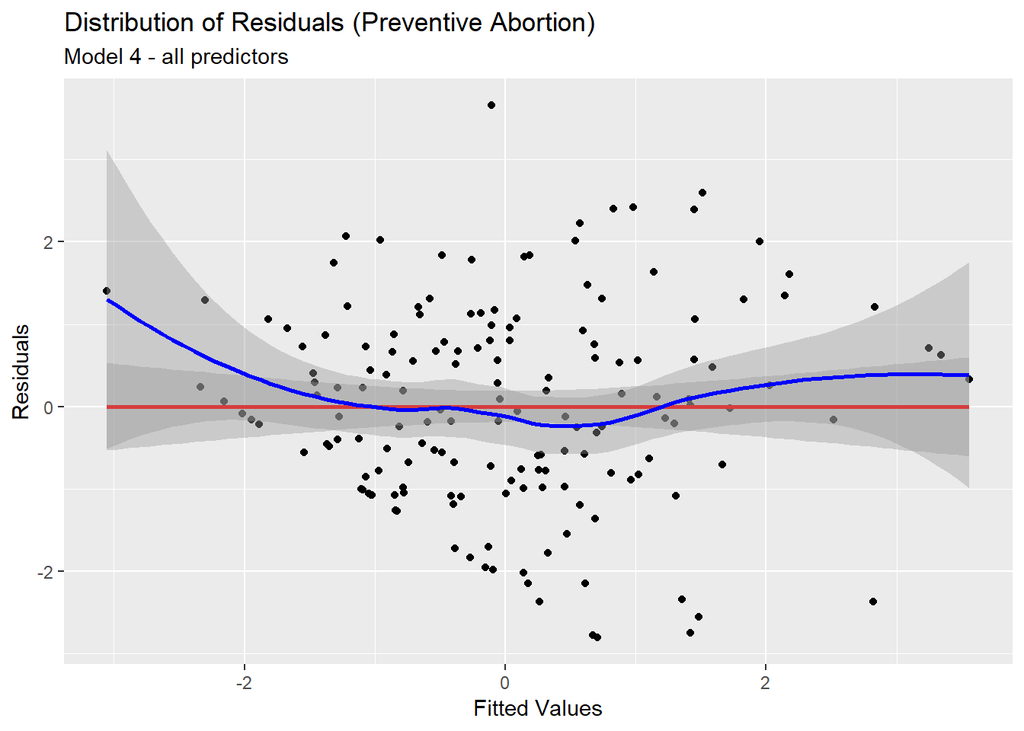

### Traumatic Abortion

Outcome: Traumatic Abortion

|  | Model 1 |  |  | Model 2 |  |  | Model 3 |  |  | Model4 |  |  |
| --- | --- | --- | --- | --- | --- | --- | --- | --- | --- | --- | --- | --- |
| Predictors | Beta | standardized 95% CI | p | Beta | standardized 95% CI | p | Beta | standardized 95% CI | p | Beta | standardized 95% CI | p |
| Ideology | 0.17 | 0.02,0.33 | **0.027** | 0.20 | 0.05,0.35 | **0.010** | 0.12 | -0.02,0.25 | 0.091 | 0.13 | -0.01,0.27 | 0.067 |
| Church att | -0.26 | -0.50,-0.03 | **0.030** | -0.30 | -0.53,-0.07 | **0.012** | -0.30 | -0.50,-0.09 | **0.006** | -0.28 | -0.48,-0.08 | **0.008** |
| Rel Person | -0.11 | -0.34,0.13 | 0.367 | -0.18 | -0.41,0.06 | 0.139 | -0.12 | -0.33,0.09 | 0.256 | -0.13 | -0.33,0.07 | 0.204 |
| Mind |  |  |  | 0.27 | 0.09,0.44 | **0.003** | 0.12 | -0.06,0.30 | 0.182 | 0.08 | -0.10,0.25 | 0.398 |
| Natural |  |  |  | -0.08 | -0.23,0.08 | 0.334 | -0.04 | -0.18,0.11 | 0.613 | -0.07 | -0.22,0.07 | 0.310 |
| Ch suff |  |  |  |  |  |  | -0.42 | -0.56,-0.28 | **<0.001** | -0.33 | -0.49,-0.18 | **<0.001** |
| Wm suff |  |  |  |  |  |  | 0.29 | 0.15,0.43 | **<0.001** | 0.35 | 0.21,0.49 | **<0.001** |
| Victimhood |  |  |  |  |  |  |  |  |  | -0.17 | -0.33,-0.01 | **0.036** |
| UW |  |  |  |  |  |  |  |  |  | 0.12 | -0.02,0.26 | 0.103 |
| Observations | 163 |  |  | 163 |  |  | 163 |  |  | 163 |  |  |
| R<sup>2</sup> / adjusted R<sup>2</sup> | 0.208 / 0.193 |  |  | 0.252 / 0.228 |  |  | 0.423 / 0.397 |  |  | 0.458 / 0.426 |  |  |

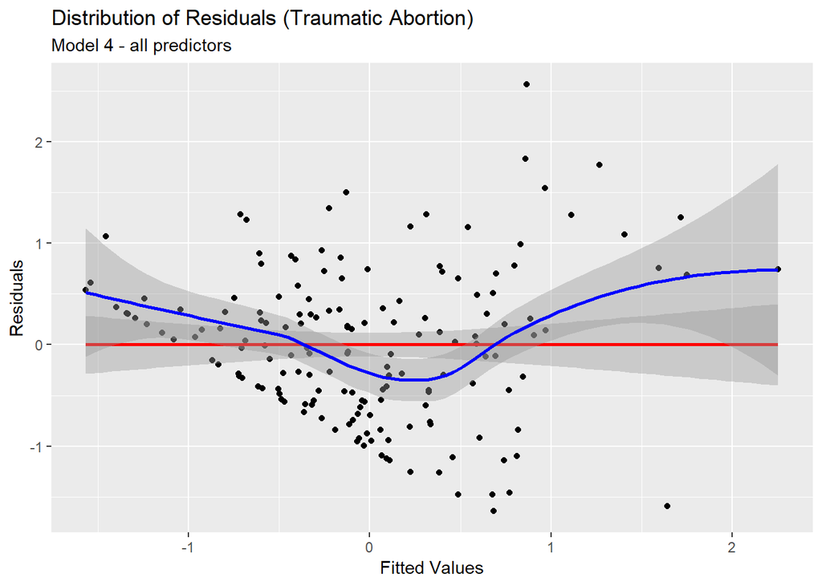

### Scenarios: It’s OK for the character to have an abortion

Outcome: Scenarios

|  | Model 1 |  |  | Model 2 |  |  | Model 3 |  |  | Model4 |  |  |
| --- | --- | --- | --- | --- | --- | --- | --- | --- | --- | --- | --- | --- |
| Predictors | Beta | standardized 95% CI | p | Beta | standardized 95% CI | p | Beta | standardized 95% CI | p | Beta | standardized 95% CI | p |
| Ideology | 0.26 | 0.11,0.41 | **0.001** | 0.26 | 0.11,0.41 | **0.001** | 0.19 | 0.05,0.33 | **0.010** | 0.21 | 0.08,0.34 | **0.002** |
| Church att | -0.02 | -0.24,0.21 | 0.891 | -0.04 | -0.27,0.19 | 0.716 | -0.04 | -0.25,0.17 | 0.696 | -0.01 | -0.20,0.19 | 0.951 |
| Rel Person | -0.32 | -0.55,-0.10 | **0.006** | -0.33 | -0.56,-0.10 | **0.006** | -0.28 | -0.50,-0.07 | **0.010** | -0.30 | -0.49,-0.11 | **0.003** |
| Mind |  |  |  | 0.09 | -0.08,0.26 | 0.300 | -0.05 | -0.23,0.13 | 0.610 | -0.13 | -0.30,0.03 | 0.122 |
| Natural |  |  |  | -0.11 | -0.26,0.04 | 0.163 | -0.07 | -0.22,0.08 | 0.358 | -0.14 | -0.27,-0.00 | 0.051 |
| Ch suff |  |  |  |  |  |  | -0.38 | -0.52,-0.23 | **<0.001** | -0.22 | -0.37,-0.08 | **0.003** |
| Wm suff |  |  |  |  |  |  | 0.23 | 0.09,0.37 | **0.002** | 0.35 | 0.21,0.48 | **<0.001** |
| Victimhood |  |  |  |  |  |  |  |  |  | -0.29 | -0.44,-0.14 | **<0.001** |
| UW |  |  |  |  |  |  |  |  |  | 0.24 | 0.11,0.38 | **0.001** |
| Observations | 163 |  |  | 163 |  |  | 163 |  |  | 163 |  |  |
| R<sup>2</sup> / adjusted R<sup>2</sup> | 0.252 / 0.238 |  |  | 0.262 / 0.239 |  |  | 0.390 / 0.363 |  |  | 0.510 / 0.481 |  |  |

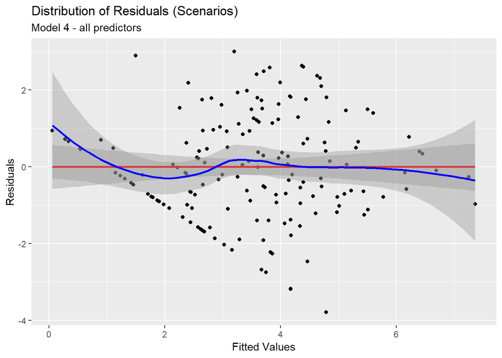

### Trade Offs: Mother’s goals vs. Fetus’ well-being

Outcome: Trade Offs

|  | Model 1 |  |  | Model 2 |  |  | Model 3 |  |  | Model4 |  |  |
| --- | --- | --- | --- | --- | --- | --- | --- | --- | --- | --- | --- | --- |
| Predictors | Beta | standardized 95% CI | p | Beta | standardized 95% CI | p | Beta | standardized 95% CI | p | Beta | standardized 95% CI | p |
| Ideology | 0.01 | -0.16,0.18 | 0.892 | 0.01 | -0.16,0.19 | 0.896 | 0.02 | -0.16,0.19 | 0.860 | 0.06 | -0.12,0.24 | 0.542 |
| Church att | 0.10 | -0.16,0.36 | 0.452 | 0.07 | -0.20,0.33 | 0.628 | 0.04 | -0.23,0.30 | 0.793 | 0.05 | -0.22,0.31 | 0.718 |
| Rel Person | -0.11 | -0.37,0.15 | 0.409 | -0.13 | -0.39,0.14 | 0.360 | -0.13 | -0.39,0.14 | 0.355 | -0.12 | -0.39,0.14 | 0.365 |
| Mind |  |  |  | 0.13 | -0.07,0.33 | 0.193 | 0.03 | -0.20,0.26 | 0.801 | -0.01 | -0.24,0.23 | 0.965 |
| Natural |  |  |  | -0.14 | -0.31,0.04 | 0.135 | -0.08 | -0.27,0.10 | 0.384 | -0.07 | -0.26,0.11 | 0.450 |
| Ch suff |  |  |  |  |  |  | -0.11 | -0.29,0.07 | 0.227 | -0.17 | -0.38,0.03 | 0.096 |
| Wm suff |  |  |  |  |  |  | -0.13 | -0.31,0.05 | 0.168 | -0.14 | -0.32,0.05 | 0.152 |
| Victimhood |  |  |  |  |  |  |  |  |  | 0.15 | -0.06,0.35 | 0.172 |
| UW |  |  |  |  |  |  |  |  |  | 0.14 | -0.05,0.33 | 0.154 |
| Observations | 163 |  |  | 163 |  |  | 163 |  |  | 163 |  |  |
| R<sup>2</sup> / adjusted R<sup>2</sup> | 0.005 / -0.014 |  |  | 0.022 / -0.009 |  |  | 0.046 / 0.003 |  |  | 0.065 / 0.010 |  |  |

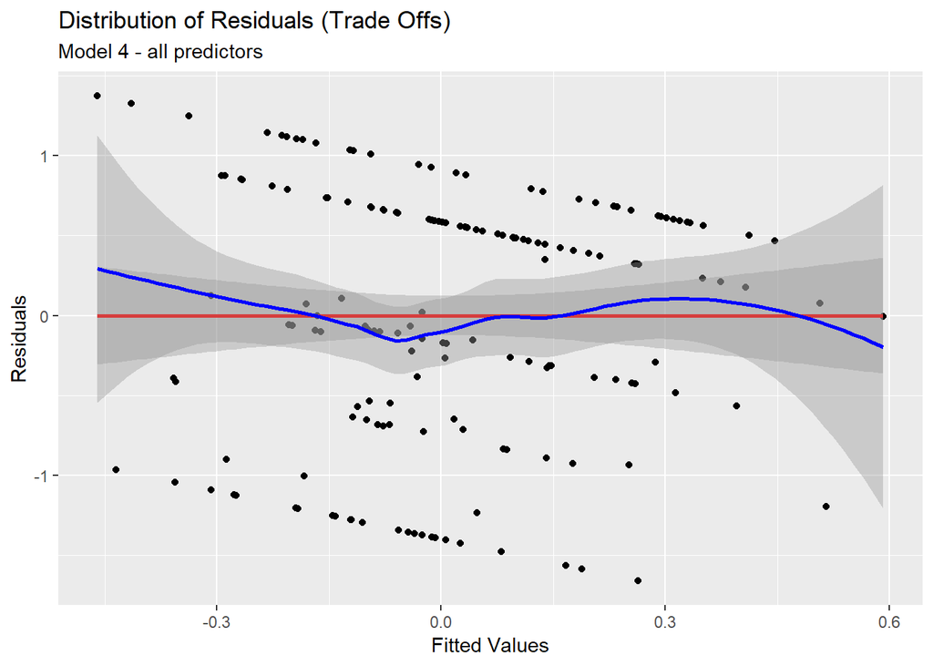